# **Week 4 Project**

## Yunjae Choi

Compiled on Tue Mar 14 22:52:24 2017.

1. Create a new data table, DailyBirths, that adds up all the births for each day across all the states. Plot out daily births vs date.

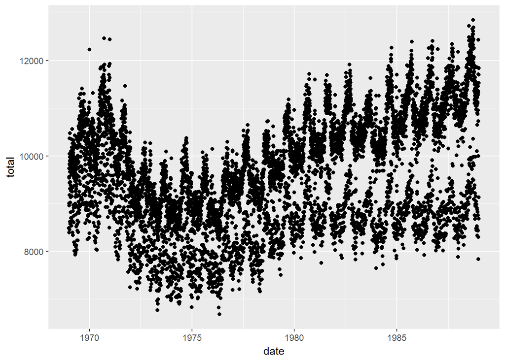

```r
data(Birthdays, package = "mosaicData")
Birthdays %>%
  group_by(date) %>%
  summarise(total = sum(births)) %>%
  ggplot(aes(x = date, y = total)) + geom_point()
```

2. To examine seasonality in birth rates, look at the number of births aggregated over all the years by

   each week

```r
library("lubridate")
Birthdays %>%
  group_by(wday) %>%
  summarise(wkbd = sum(births))
```

```
## # A tibble: 7 × 2
##    wday     wkbd
##   <ord>    <int>
## 1   Sun  8647150
## 2   Mon 10372019
## 3  Tues 10813928
## 4   Wed 10533539
## 5 Thurs 10434966
## 6   Fri 10593324
## 7   Sat  9091612
```

```
each month
```

```r
Birthdays %>%
  group_by(month) %>%
  summarise(wkbd = sum(births))
```

```
## # A tibble: 12 × 2
##    month    wkbd
##    <int>   <int>
## 1      1 5759165
## 2      2 5362946
## 3      3 5868140
## 4      4 5560903
## 5      5 5785220
## 6      6 5758696
## 7      7 6220295
## 8      8 6309764
## 9      9 6206173
## 10    10 6055372
## 11    11 5695488
## 12    12 5904376
```

```
each Julian day
```

```r
Birthdays %>%
  group_by(yday(date)) %>%
  summarise(wkbd = sum(births))
```

```
## # A tibble: 366 × 2
##    `yday(date)`   wkbd
##           <dbl>  <int>
## 1             1 160369
## 2             2 169896
## 3             3 180036
## 4             4 182854
## 5             5 184145
## 6             6 186726
## 7             7 188277
## 8             8 185186
## 9             9 181511
## 10           10 183668
## # ... with 356 more rows
```

3. To examine patterns within the week, look at the number of births by day of the week.

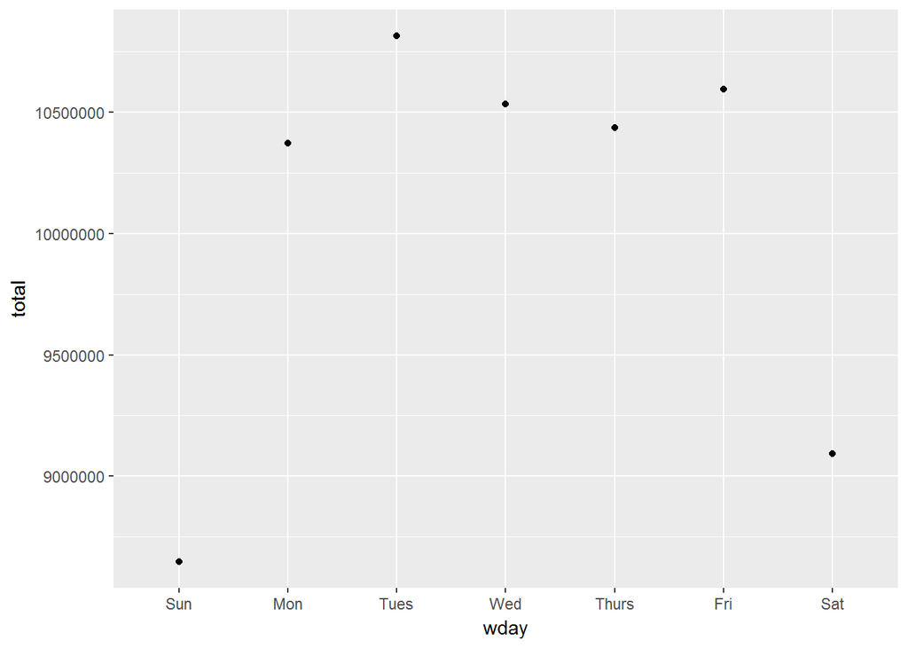

```r
Birthdays %>%
  group_by(wday) %>%
  summarise(total = sum(births)) %>%
  ggplot(aes(x = wday, y = total)) + geom_point()
```

4. Pick a two-year span of the Birthdays that falls in the 1980s, say, 1980/1981. Extract out the data just in this interval, calling it MyTwoYears. (Hint: filter(), year()). Plot out the births in this two-year span day by day. Color each date according to its day of the week. Explain the pattern that you see.

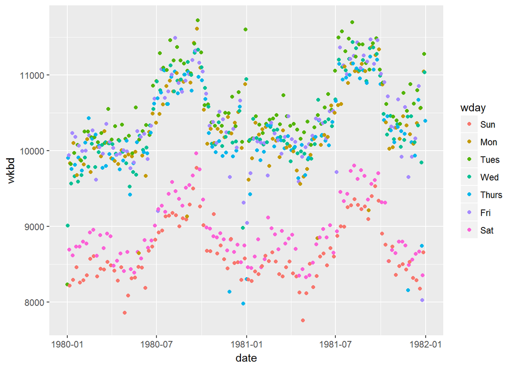

```r
MyTwoYears <- Birthdays %>%
  filter(year(date) %in% c(1980,1981)) %>%
  group_by(date, wday) %>%
  summarise(wkbd = sum(births)) %>%
  ggplot(aes(x = date, y = wkbd)) + geom_point(aes(color = wday))
MyTwoYears
```

- Plotting out the holidays (Thanks Giving) - blue dots in the bottom
- lower on the weekends because sea sections are scheduled usually
- summer peaks / winter troughs

*Births and holidays*

5. A few days each year don’t follow the pattern in (4). We’re going to examine the hypothesis that these are holidays. You can find a data set listing US federal holidays at http://tiny.cc/dcf/US-Holidays.csv. Read it in as follows:11 The point of the lubridate::dmy() function is to convert the character-string date stored in the CSV to a POSIX date-number.

```r
Holidays <- read.csv("http://tiny.cc/dcf/US-Holidays.csv") %>%
  mutate(date = as.POSIXct(lubridate::dmy(date)))
```

6. Add a couple of layers to your plot from (4).

   ```
   1. Draw a vertical bar at each date which is a holiday. You’ll use the geom_vline() glyph. You can give a data = argument to geom_vline() to tell it to plot out the information from Holidays rather than MyTwoYears.
   2. Add a text label to each of the vertical bars to identify which holiday it is. Use the geom_text() glyph.
   ```

7. The plot in (6) is too busy. Let’s explore some other ways to display the data to make it clearer to the view that holidays tend to be low-birth days.

   Add a variable to MyTwoYears called is_holiday. It should be TRUE when the day is a holiday, and FALSE otherwise. One way to do this is with the transformation verb %in%, for instance,

   > is_holiday = date %in% Holidays$date

   Make a new plot where you map is_holiday to the shape or the size aesthetics, or perhaps for faceting. Or perhaps change the way color is used in the graph to show weekends and holidays separately from non-holiday weekdays. Make the graph as simple as you can until you get one that clearly tells the story. You may want to simplify by eliminating any components of the graph (e.g. holiday labels? dots? lines? vertical lines?) that aren’t essential to telling the story.

```r
hn <- Holidays %>%
  mutate(date = as.POSIXct(lubridate::dmy(date)))
```

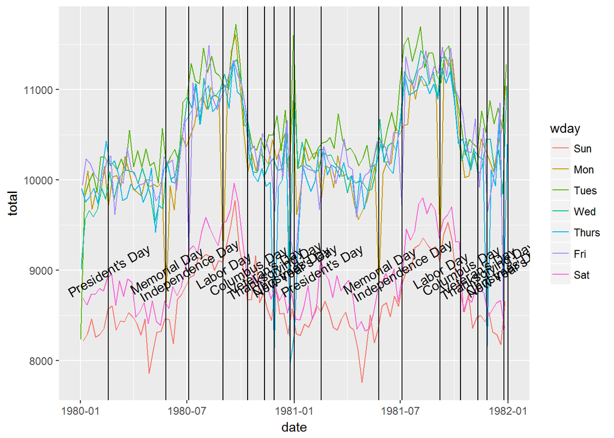

```r
hn <- Holidays %>%
  filter(year(date) %in% c(1980,1981))


MyTwoYears <- Birthdays %>%
  filter(year(date) %in% c(1980,1981)) %>%
  group_by(date, wday) %>%
  summarise(total = sum(births)) %>%
  ggplot(aes(x = date, y = total)) + geom_line(aes(color = wday)) + geom_vline(data = hn, aes(xintercept = as.numeric(date))) + geom_text(data = hn, aes(x=date,label = holiday),y=9000,angle=30)

MyTwoYears
```